# Risk Factor Analysis

## Outcome Variable

**Outcome Variable:** pers_wasted624

## Predictor Variables

**Intervention Variable:** ever_sunderweight06

**Adjustment Set:**

unadjusted

## Stratifying Variables

The analysis was stratified on these variable(s):

- studyid
- country

## Data Summary

| studyid | country | ever_sunderweight06 | pers_wasted624 | n_cell | n |
| --- | --- | --- | --- | --- | --- |
| ki0047075b-MAL-ED | BANGLADESH | 0 | 0 | 212 | 239 |
| ki0047075b-MAL-ED | BANGLADESH | 0 | 1 | 15 | 239 |
| ki0047075b-MAL-ED | BANGLADESH | 1 | 0 | 9 | 239 |
| ki0047075b-MAL-ED | BANGLADESH | 1 | 1 | 3 | 239 |
| ki0047075b-MAL-ED | BRAZIL | 0 | 0 | 200 | 202 |
| ki0047075b-MAL-ED | BRAZIL | 0 | 1 | 2 | 202 |
| ki0047075b-MAL-ED | BRAZIL | 1 | 0 | 0 | 202 |
| ki0047075b-MAL-ED | BRAZIL | 1 | 1 | 0 | 202 |
| ki0047075b-MAL-ED | INDIA | 0 | 0 | 188 | 234 |
| ki0047075b-MAL-ED | INDIA | 0 | 1 | 17 | 234 |
| ki0047075b-MAL-ED | INDIA | 1 | 0 | 18 | 234 |
| ki0047075b-MAL-ED | INDIA | 1 | 1 | 11 | 234 |
| ki0047075b-MAL-ED | NEPAL | 0 | 0 | 223 | 234 |
| ki0047075b-MAL-ED | NEPAL | 0 | 1 | 1 | 234 |
| ki0047075b-MAL-ED | NEPAL | 1 | 0 | 9 | 234 |
| ki0047075b-MAL-ED | NEPAL | 1 | 1 | 1 | 234 |
| ki0047075b-MAL-ED | PERU | 0 | 0 | 254 | 264 |
| ki0047075b-MAL-ED | PERU | 0 | 1 | 2 | 264 |
| ki0047075b-MAL-ED | PERU | 1 | 0 | 8 | 264 |
| ki0047075b-MAL-ED | PERU | 1 | 1 | 0 | 264 |
| ki0047075b-MAL-ED | SOUTH AFRICA | 0 | 0 | 248 | 258 |
| ki0047075b-MAL-ED | SOUTH AFRICA | 0 | 1 | 2 | 258 |
| ki0047075b-MAL-ED | SOUTH AFRICA | 1 | 0 | 8 | 258 |
| ki0047075b-MAL-ED | SOUTH AFRICA | 1 | 1 | 0 | 258 |
| ki0047075b-MAL-ED | TANZANIA, UNITED REPUBLIC OF | 0 | 0 | 237 | 244 |
| ki0047075b-MAL-ED | TANZANIA, UNITED REPUBLIC OF | 0 | 1 | 0 | 244 |
| ki0047075b-MAL-ED | TANZANIA, UNITED REPUBLIC OF | 1 | 0 | 7 | 244 |
| ki0047075b-MAL-ED | TANZANIA, UNITED REPUBLIC OF | 1 | 1 | 0 | 244 |
| ki1000108-CMC-V-BCS-2002 | INDIA | 0 | 0 | 287 | 373 |
| ki1000108-CMC-V-BCS-2002 | INDIA | 0 | 1 | 12 | 373 |

[output cut: 118 more lines]

The following strata were considered:

- studyid: ki0047075b-MAL-ED, country: BANGLADESH
- studyid: ki0047075b-MAL-ED, country: BRAZIL
- studyid: ki0047075b-MAL-ED, country: INDIA
- studyid: ki0047075b-MAL-ED, country: NEPAL
- studyid: ki0047075b-MAL-ED, country: PERU
- studyid: ki0047075b-MAL-ED, country: SOUTH AFRICA
- studyid: ki0047075b-MAL-ED, country: TANZANIA, UNITED REPUBLIC OF
- studyid: ki1000108-CMC-V-BCS-2002, country: INDIA
- studyid: ki1000108-IRC, country: INDIA
- studyid: ki1000109-EE, country: PAKISTAN
- studyid: ki1000109-ResPak, country: PAKISTAN
- studyid: ki1000304-VITAMIN-A, country: INDIA
- studyid: ki1000304b-SAS-CompFeed, country: INDIA
- studyid: ki1000304b-SAS-FoodSuppl, country: INDIA
- studyid: ki1017093-NIH-Birth, country: BANGLADESH
- studyid: ki1017093b-PROVIDE, country: BANGLADESH
- studyid: ki1017093c-NIH-Crypto, country: BANGLADESH
- studyid: ki1066203-TanzaniaChild2, country: TANZANIA, UNITED REPUBLIC OF
- studyid: ki1101329-Keneba, country: GAMBIA
- studyid: ki1112895-Burkina Faso Zn, country: BURKINA FASO
- studyid: ki1112895-Guatemala BSC, country: GUATEMALA
- studyid: ki1113344-GMS-Nepal, country: NEPAL
- studyid: ki1114097-CMIN, country: BANGLADESH
- studyid: ki1114097-CMIN, country: BRAZIL
- studyid: ki1114097-CMIN, country: GUINEA-BISSAU
- studyid: ki1114097-CMIN, country: PERU
- studyid: ki1114097-CONTENT, country: PERU
- studyid: ki1119695-PROBIT, country: BELARUS
- studyid: ki1126311-ZVITAMBO, country: ZIMBABWE
- studyid: ki1135781-COHORTS, country: GUATEMALA
- studyid: ki1135781-COHORTS, country: INDIA
- studyid: ki1135781-COHORTS, country: PHILIPPINES
- studyid: ki1148112-iLiNS-DOSE, country: MALAWI
- studyid: ki1148112-iLiNS-DYAD-M, country: MALAWI
- studyid: ki1148112-LCNI-5, country: MALAWI
- studyid: kiGH5241-JiVitA-3, country: BANGLADESH
- studyid: kiGH5241-JiVitA-4, country: BANGLADESH

### Dropped Strata

Some strata were dropped due to rare outcomes:

- studyid: ki0047075b-MAL-ED, country: BANGLADESH
- studyid: ki0047075b-MAL-ED, country: BRAZIL
- studyid: ki0047075b-MAL-ED, country: NEPAL
- studyid: ki0047075b-MAL-ED, country: PERU
- studyid: ki0047075b-MAL-ED, country: SOUTH AFRICA
- studyid: ki0047075b-MAL-ED, country: TANZANIA, UNITED REPUBLIC OF
- studyid: ki1112895-Burkina Faso Zn, country: BURKINA FASO
- studyid: ki1112895-Guatemala BSC, country: GUATEMALA
- studyid: ki1114097-CMIN, country: BRAZIL
- studyid: ki1114097-CMIN, country: GUINEA-BISSAU
- studyid: ki1114097-CMIN, country: PERU
- studyid: ki1114097-CONTENT, country: PERU
- studyid: ki1119695-PROBIT, country: BELARUS
- studyid: ki1148112-LCNI-5, country: MALAWI

## Methods Detail

We’re interested in the causal parameters $E[Y_a]$ for all values of $a \in \mathcal{A}$. These parameters represent the mean outcome if, possibly contrary to fact, we intervened to set all units to have $A=a$. Under the randomization and positivity assumptions, these are identified by the statistical parameters $\psi_a=E_W[E_{Y|A,W}(Y|A=a,W)]$. In addition, we’re interested in the mean of $Y$, $E[Y]$ under no intervention (the observed mean). We will estimate these parameters by using SuperLearner to fit the relevant likelihood factors – $E_{Y|A,W}(Y|A=a,W)$ and $p(A=a|W)$, and then updating our likelihood fit using a joint TMLE.

For unadjusted analyses ($W=\{\}$), initial likelihoods were estimated using Lrnr_glm to estimate the simple $E(Y|A)$ and Lrnr_mean to estimate $p(A)$. For adjusted analyses, a small library containing Lrnr_glmnet, Lrnr_xgboost, and Lrnr_mean was used.

Having estimated these parameters, we will then use the delta method to estimate relative risks and attributable risks relative to a prespecified baseline level of $A$.

# Results Detail

## Results Plots

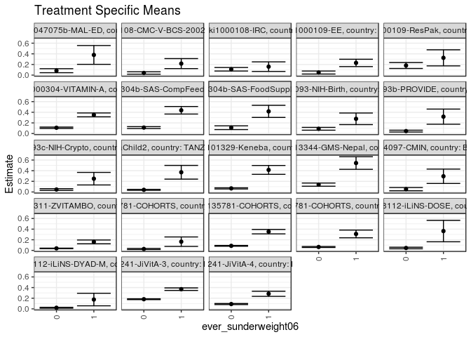

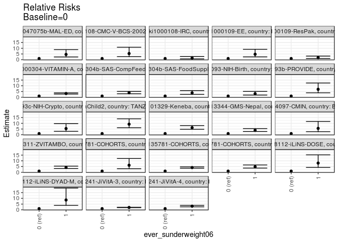

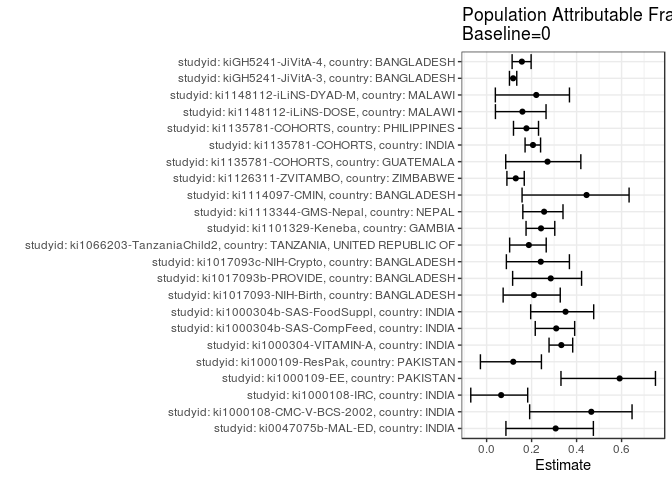

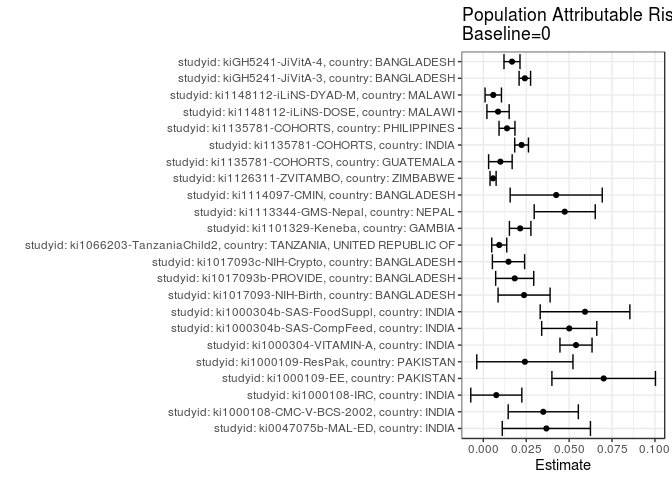

## Results Table

### Parameter: TSM

| studyid | country | intervention_level | baseline_level | estimate | ci_lower | ci_upper |
| --- | --- | --- | --- | --- | --- | --- |
| ki0047075b-MAL-ED | INDIA | 0 | NA | 0.0829268 | 0.0450956 | 0.1207581 |
| ki0047075b-MAL-ED | INDIA | 1 | NA | 0.3793103 | 0.2023346 | 0.5562861 |
| ki1000108-CMC-V-BCS-2002 | INDIA | 0 | NA | 0.0401338 | 0.0178568 | 0.0624107 |
| ki1000108-CMC-V-BCS-2002 | INDIA | 1 | NA | 0.2162162 | 0.1222964 | 0.3101361 |
| ki1000108-IRC | INDIA | 0 | NA | 0.1095101 | 0.0766132 | 0.1424070 |
| ki1000108-IRC | INDIA | 1 | NA | 0.1587302 | 0.0683849 | 0.2490754 |
| ki1000109-EE | PAKISTAN | 0 | NA | 0.0484582 | 0.0204865 | 0.0764298 |
| ki1000109-EE | PAKISTAN | 1 | NA | 0.2291667 | 0.1604268 | 0.2979066 |
| ki1000109-ResPak | PAKISTAN | 0 | NA | 0.1803279 | 0.1244984 | 0.2361573 |
| ki1000109-ResPak | PAKISTAN | 1 | NA | 0.3243243 | 0.1731440 | 0.4755047 |
| ki1000304-VITAMIN-A | INDIA | 0 | NA | 0.1085914 | 0.0958547 | 0.1213280 |
| ki1000304-VITAMIN-A | INDIA | 1 | NA | 0.3505311 | 0.3140959 | 0.3869663 |
| ki1000304b-SAS-CompFeed | INDIA | 0 | NA | 0.1117904 | 0.0937654 | 0.1298154 |
| ki1000304b-SAS-CompFeed | INDIA | 1 | NA | 0.4375000 | 0.3667197 | 0.5082803 |
| ki1000304b-SAS-FoodSuppl | INDIA | 0 | NA | 0.1096346 | 0.0742914 | 0.1449777 |
| ki1000304b-SAS-FoodSuppl | INDIA | 1 | NA | 0.4166667 | 0.3026371 | 0.5306963 |
| ki1017093-NIH-Birth | BANGLADESH | 0 | NA | 0.0890869 | 0.0627118 | 0.1154619 |
| ki1017093-NIH-Birth | BANGLADESH | 1 | NA | 0.2769231 | 0.1680335 | 0.3858126 |
| ki1017093b-PROVIDE | BANGLADESH | 0 | NA | 0.0458554 | 0.0286242 | 0.0630866 |
| ki1017093b-PROVIDE | BANGLADESH | 1 | NA | 0.3170732 | 0.1745188 | 0.4596275 |
| ki1017093c-NIH-Crypto | BANGLADESH | 0 | NA | 0.0462687 | 0.0303514 | 0.0621859 |
| ki1017093c-NIH-Crypto | BANGLADESH | 1 | NA | 0.2500000 | 0.1322264 | 0.3677736 |
| ki1066203-TanzaniaChild2 | TANZANIA, UNITED REPUBLIC OF | 0 | NA | 0.0401714 | 0.0312621 | 0.0490807 |
| ki1066203-TanzaniaChild2 | TANZANIA, UNITED REPUBLIC OF | 1 | NA | 0.3703704 | 0.2415380 | 0.4992027 |
| ki1101329-Keneba | GAMBIA | 0 | NA | 0.0673171 | 0.0564678 | 0.0781663 |
| ki1101329-Keneba | GAMBIA | 1 | NA | 0.4148148 | 0.3316855 | 0.4979442 |
| ki1113344-GMS-Nepal | NEPAL | 0 | NA | 0.1381323 | 0.1082779 | 0.1679867 |
| ki1113344-GMS-Nepal | NEPAL | 1 | NA | 0.5441176 | 0.4256391 | 0.6625962 |
| ki1114097-CMIN | BANGLADESH | 0 | NA | 0.0531401 | 0.0225216 | 0.0837586 |
| ki1114097-CMIN | BANGLADESH | 1 | NA | 0.2954545 | 0.1603754 | 0.4305337 |
| ki1126311-ZVITAMBO | ZIMBABWE | 0 | NA | 0.0381838 | 0.0340283 | 0.0423393 |
| ki1126311-ZVITAMBO | ZIMBABWE | 1 | NA | 0.1600000 | 0.1240712 | 0.1959288 |
| ki1135781-COHORTS | GUATEMALA | 0 | NA | 0.0267753 | 0.0159744 | 0.0375762 |
| ki1135781-COHORTS | GUATEMALA | 1 | NA | 0.1641791 | 0.0754306 | 0.2529276 |
| ki1135781-COHORTS | INDIA | 0 | NA | 0.0858951 | 0.0785092 | 0.0932810 |
| ki1135781-COHORTS | INDIA | 1 | NA | 0.3524752 | 0.3108045 | 0.3941460 |
| ki1135781-COHORTS | PHILIPPINES | 0 | NA | 0.0641814 | 0.0547631 | 0.0735997 |
| ki1135781-COHORTS | PHILIPPINES | 1 | NA | 0.3096774 | 0.2368757 | 0.3824792 |
| ki1148112-iLiNS-DOSE | MALAWI | 0 | NA | 0.0453401 | 0.0308600 | 0.0598201 |
| ki1148112-iLiNS-DOSE | MALAWI | 1 | NA | 0.3636364 | 0.1625006 | 0.5647722 |
| ki1148112-iLiNS-DYAD-M | MALAWI | 0 | NA | 0.0204678 | 0.0117997 | 0.0291359 |
| ki1148112-iLiNS-DYAD-M | MALAWI | 1 | NA | 0.1750000 | 0.0571939 | 0.2928061 |
| kiGH5241-JiVitA-3 | BANGLADESH | 0 | NA | 0.1810046 | 0.1732455 | 0.1887637 |
| kiGH5241-JiVitA-3 | BANGLADESH | 1 | NA | 0.3699232 | 0.3460950 | 0.3937513 |
| kiGH5241-JiVitA-4 | BANGLADESH | 0 | NA | 0.0899654 | 0.0797692 | 0.1001616 |
| kiGH5241-JiVitA-4 | BANGLADESH | 1 | NA | 0.2831050 | 0.2349807 | 0.3312293 |

### Parameter: E(Y)

| studyid | country | intervention_level | baseline_level | estimate | ci_lower | ci_upper |
| --- | --- | --- | --- | --- | --- | --- |
| ki0047075b-MAL-ED | INDIA | NA | NA | 0.1196581 | 0.0779840 | 0.1613323 |
| ki1000108-CMC-V-BCS-2002 | INDIA | NA | NA | 0.0750670 | 0.0482904 | 0.1018437 |
| ki1000108-IRC | INDIA | NA | NA | 0.1170732 | 0.0859146 | 0.1482317 |
| ki1000109-EE | PAKISTAN | NA | NA | 0.1185984 | 0.0856546 | 0.1515422 |
| ki1000109-ResPak | PAKISTAN | NA | NA | 0.2045455 | 0.1511224 | 0.2579685 |
| ki1000304-VITAMIN-A | INDIA | NA | NA | 0.1626016 | 0.1492881 | 0.1759151 |
| ki1000304b-SAS-CompFeed | INDIA | NA | NA | 0.1618625 | 0.1426768 | 0.1810483 |
| ki1000304b-SAS-FoodSuppl | INDIA | NA | NA | 0.1689008 | 0.1308276 | 0.2069740 |
| ki1017093-NIH-Birth | BANGLADESH | NA | NA | 0.1128405 | 0.0854611 | 0.1402198 |
| ki1017093b-PROVIDE | BANGLADESH | NA | NA | 0.0641447 | 0.0446535 | 0.0836359 |
| ki1017093c-NIH-Crypto | BANGLADESH | NA | NA | 0.0609418 | 0.0434802 | 0.0784034 |
| ki1066203-TanzaniaChild2 | TANZANIA, UNITED REPUBLIC OF | NA | NA | 0.0494534 | 0.0397554 | 0.0591514 |
| ki1101329-Keneba | GAMBIA | NA | NA | 0.0887872 | 0.0768581 | 0.1007163 |
| ki1113344-GMS-Nepal | NEPAL | NA | NA | 0.1855670 | 0.1539560 | 0.2171780 |
| ki1114097-CMIN | BANGLADESH | NA | NA | 0.0956175 | 0.0591654 | 0.1320697 |
| ki1126311-ZVITAMBO | ZIMBABWE | NA | NA | 0.0438689 | 0.0395328 | 0.0482049 |
| ki1135781-COHORTS | GUATEMALA | NA | NA | 0.0367171 | 0.0245975 | 0.0488367 |
| ki1135781-COHORTS | INDIA | NA | NA | 0.1082022 | 0.1003643 | 0.1160400 |
| ki1135781-COHORTS | PHILIPPINES | NA | NA | 0.0779833 | 0.0679723 | 0.0879943 |
| ki1148112-iLiNS-DOSE | MALAWI | NA | NA | 0.0539216 | 0.0384151 | 0.0694281 |
| ki1148112-iLiNS-DYAD-M | MALAWI | NA | NA | 0.0262664 | 0.0166615 | 0.0358713 |
| kiGH5241-JiVitA-3 | BANGLADESH | NA | NA | 0.2052021 | 0.1976666 | 0.2127376 |
| kiGH5241-JiVitA-4 | BANGLADESH | NA | NA | 0.1066772 | 0.0962568 | 0.1170977 |

### Parameter: RR

| studyid | country | intervention_level | baseline_level | estimate | ci_lower | ci_upper |
| --- | --- | --- | --- | --- | --- | --- |
| ki0047075b-MAL-ED | INDIA | 0 | 0 | 1.000000 | 1.0000000 | 1.000000 |
| ki0047075b-MAL-ED | INDIA | 1 | 0 | 4.574037 | 2.3817990 | 8.784037 |
| ki1000108-CMC-V-BCS-2002 | INDIA | 0 | 0 | 1.000000 | 1.0000000 | 1.000000 |
| ki1000108-CMC-V-BCS-2002 | INDIA | 1 | 0 | 5.387387 | 2.6624069 | 10.901393 |
| ki1000108-IRC | INDIA | 0 | 0 | 1.000000 | 1.0000000 | 1.000000 |
| ki1000108-IRC | INDIA | 1 | 0 | 1.449457 | 0.7615529 | 2.758739 |
| ki1000109-EE | PAKISTAN | 0 | 0 | 1.000000 | 1.0000000 | 1.000000 |
| ki1000109-EE | PAKISTAN | 1 | 0 | 4.729167 | 2.4675652 | 9.063597 |
| ki1000109-ResPak | PAKISTAN | 0 | 0 | 1.000000 | 1.0000000 | 1.000000 |
| ki1000109-ResPak | PAKISTAN | 1 | 0 | 1.798526 | 1.0277583 | 3.147331 |
| ki1000304-VITAMIN-A | INDIA | 0 | 0 | 1.000000 | 1.0000000 | 1.000000 |
| ki1000304-VITAMIN-A | INDIA | 1 | 0 | 3.227983 | 2.7597441 | 3.775667 |
| ki1000304b-SAS-CompFeed | INDIA | 0 | 0 | 1.000000 | 1.0000000 | 1.000000 |
| ki1000304b-SAS-CompFeed | INDIA | 1 | 0 | 3.913574 | 3.0195343 | 5.072326 |
| ki1000304b-SAS-FoodSuppl | INDIA | 0 | 0 | 1.000000 | 1.0000000 | 1.000000 |
| ki1000304b-SAS-FoodSuppl | INDIA | 1 | 0 | 3.800505 | 2.4899506 | 5.800853 |
| ki1017093-NIH-Birth | BANGLADESH | 0 | 0 | 1.000000 | 1.0000000 | 1.000000 |
| ki1017093-NIH-Birth | BANGLADESH | 1 | 0 | 3.108462 | 1.9001283 | 5.085200 |
| ki1017093b-PROVIDE | BANGLADESH | 0 | 0 | 1.000000 | 1.0000000 | 1.000000 |
| ki1017093b-PROVIDE | BANGLADESH | 1 | 0 | 6.914634 | 3.8485142 | 12.423538 |
| ki1017093c-NIH-Crypto | BANGLADESH | 0 | 0 | 1.000000 | 1.0000000 | 1.000000 |
| ki1017093c-NIH-Crypto | BANGLADESH | 1 | 0 | 5.403226 | 3.0151882 | 9.682596 |
| ki1066203-TanzaniaChild2 | TANZANIA, UNITED REPUBLIC OF | 0 | 0 | 1.000000 | 1.0000000 | 1.000000 |
| ki1066203-TanzaniaChild2 | TANZANIA, UNITED REPUBLIC OF | 1 | 0 | 9.219753 | 6.1031989 | 13.927753 |
| ki1101329-Keneba | GAMBIA | 0 | 0 | 1.000000 | 1.0000000 | 1.000000 |
| ki1101329-Keneba | GAMBIA | 1 | 0 | 6.162104 | 4.7647759 | 7.969216 |
| ki1113344-GMS-Nepal | NEPAL | 0 | 0 | 1.000000 | 1.0000000 | 1.000000 |
| ki1113344-GMS-Nepal | NEPAL | 1 | 0 | 3.939105 | 2.8983939 | 5.353499 |
| ki1114097-CMIN | BANGLADESH | 0 | 0 | 1.000000 | 1.0000000 | 1.000000 |
| ki1114097-CMIN | BANGLADESH | 1 | 0 | 5.559917 | 2.6645841 | 11.601316 |
| ki1126311-ZVITAMBO | ZIMBABWE | 0 | 0 | 1.000000 | 1.0000000 | 1.000000 |
| ki1126311-ZVITAMBO | ZIMBABWE | 1 | 0 | 4.190256 | 3.2648867 | 5.377904 |
| ki1135781-COHORTS | GUATEMALA | 0 | 0 | 1.000000 | 1.0000000 | 1.000000 |
| ki1135781-COHORTS | GUATEMALA | 1 | 0 | 6.131733 | 3.1236250 | 12.036703 |
| ki1135781-COHORTS | INDIA | 0 | 0 | 1.000000 | 1.0000000 | 1.000000 |
| ki1135781-COHORTS | INDIA | 1 | 0 | 4.103554 | 3.5454558 | 4.749504 |
| ki1135781-COHORTS | PHILIPPINES | 0 | 0 | 1.000000 | 1.0000000 | 1.000000 |
| ki1135781-COHORTS | PHILIPPINES | 1 | 0 | 4.825034 | 3.6571631 | 6.365850 |
| ki1148112-iLiNS-DOSE | MALAWI | 0 | 0 | 1.000000 | 1.0000000 | 1.000000 |
| ki1148112-iLiNS-DOSE | MALAWI | 1 | 0 | 8.020202 | 4.2344866 | 15.190422 |
| ki1148112-iLiNS-DYAD-M | MALAWI | 0 | 0 | 1.000000 | 1.0000000 | 1.000000 |
| ki1148112-iLiNS-DYAD-M | MALAWI | 1 | 0 | 8.550000 | 3.8598198 | 18.939355 |
| kiGH5241-JiVitA-3 | BANGLADESH | 0 | 0 | 1.000000 | 1.0000000 | 1.000000 |
| kiGH5241-JiVitA-3 | BANGLADESH | 1 | 0 | 2.043722 | 1.8904411 | 2.209432 |
| kiGH5241-JiVitA-4 | BANGLADESH | 0 | 0 | 1.000000 | 1.0000000 | 1.000000 |
| kiGH5241-JiVitA-4 | BANGLADESH | 1 | 0 | 3.146821 | 2.5621334 | 3.864937 |

### Parameter: PAR

| studyid | country | intervention_level | baseline_level | estimate | ci_lower | ci_upper |
| --- | --- | --- | --- | --- | --- | --- |
| ki0047075b-MAL-ED | INDIA | 0 | NA | 0.0367313 | 0.0110355 | 0.0624271 |
| ki1000108-CMC-V-BCS-2002 | INDIA | 0 | NA | 0.0349332 | 0.0144971 | 0.0553694 |
| ki1000108-IRC | INDIA | 0 | NA | 0.0075631 | -0.0073107 | 0.0224369 |
| ki1000109-EE | PAKISTAN | 0 | NA | 0.0701402 | 0.0399699 | 0.1003106 |
| ki1000109-ResPak | PAKISTAN | 0 | NA | 0.0242176 | -0.0038095 | 0.0522446 |
| ki1000304-VITAMIN-A | INDIA | 0 | NA | 0.0540103 | 0.0446585 | 0.0633620 |
| ki1000304b-SAS-CompFeed | INDIA | 0 | NA | 0.0500721 | 0.0340106 | 0.0661337 |
| ki1000304b-SAS-FoodSuppl | INDIA | 0 | NA | 0.0592663 | 0.0331384 | 0.0853941 |
| ki1017093-NIH-Birth | BANGLADESH | 0 | NA | 0.0237536 | 0.0085903 | 0.0389169 |
| ki1017093b-PROVIDE | BANGLADESH | 0 | NA | 0.0182894 | 0.0071972 | 0.0293815 |
| ki1017093c-NIH-Crypto | BANGLADESH | 0 | NA | 0.0146732 | 0.0052900 | 0.0240563 |
| ki1066203-TanzaniaChild2 | TANZANIA, UNITED REPUBLIC OF | 0 | NA | 0.0092820 | 0.0049073 | 0.0136567 |
| ki1101329-Keneba | GAMBIA | 0 | NA | 0.0214701 | 0.0152138 | 0.0277264 |
| ki1113344-GMS-Nepal | NEPAL | 0 | NA | 0.0474347 | 0.0296515 | 0.0652180 |
| ki1114097-CMIN | BANGLADESH | 0 | NA | 0.0424774 | 0.0156456 | 0.0693093 |
| ki1126311-ZVITAMBO | ZIMBABWE | 0 | NA | 0.0056850 | 0.0039116 | 0.0074585 |
| ki1135781-COHORTS | GUATEMALA | 0 | NA | 0.0099417 | 0.0030783 | 0.0168052 |
| ki1135781-COHORTS | INDIA | 0 | NA | 0.0223070 | 0.0183058 | 0.0263083 |
| ki1135781-COHORTS | PHILIPPINES | 0 | NA | 0.0138019 | 0.0091662 | 0.0184376 |
| ki1148112-iLiNS-DOSE | MALAWI | 0 | NA | 0.0085815 | 0.0020941 | 0.0150689 |
| ki1148112-iLiNS-DYAD-M | MALAWI | 0 | NA | 0.0057986 | 0.0010281 | 0.0105691 |
| kiGH5241-JiVitA-3 | BANGLADESH | 0 | NA | 0.0241975 | 0.0208497 | 0.0275453 |
| kiGH5241-JiVitA-4 | BANGLADESH | 0 | NA | 0.0167118 | 0.0120475 | 0.0213761 |

### Parameter: PAF

| studyid | country | intervention_level | baseline_level | estimate | ci_lower | ci_upper |
| --- | --- | --- | --- | --- | --- | --- |
| ki0047075b-MAL-ED | INDIA | 0 | NA | 0.3069686 | 0.0858243 | 0.4746169 |
| ki1000108-CMC-V-BCS-2002 | INDIA | 0 | NA | 0.4653607 | 0.1913083 | 0.6465413 |
| ki1000108-IRC | INDIA | 0 | NA | 0.0646013 | -0.0704727 | 0.1826315 |
| ki1000109-EE | PAKISTAN | 0 | NA | 0.5914097 | 0.3305661 | 0.7506161 |
| ki1000109-ResPak | PAKISTAN | 0 | NA | 0.1183971 | -0.0276046 | 0.2436549 |
| ki1000304-VITAMIN-A | INDIA | 0 | NA | 0.3321631 | 0.2775064 | 0.3826850 |
| ki1000304b-SAS-CompFeed | INDIA | 0 | NA | 0.3093498 | 0.2162033 | 0.3914267 |
| ki1000304b-SAS-FoodSuppl | INDIA | 0 | NA | 0.3508938 | 0.1958744 | 0.4760286 |
| ki1017093-NIH-Birth | BANGLADESH | 0 | NA | 0.2105061 | 0.0734455 | 0.3272920 |
| ki1017093b-PROVIDE | BANGLADESH | 0 | NA | 0.2851264 | 0.1156443 | 0.4221281 |
| ki1017093c-NIH-Crypto | BANGLADESH | 0 | NA | 0.2407734 | 0.0878252 | 0.3680761 |
| ki1066203-TanzaniaChild2 | TANZANIA, UNITED REPUBLIC OF | 0 | NA | 0.1876920 | 0.1023519 | 0.2649189 |
| ki1101329-Keneba | GAMBIA | 0 | NA | 0.2418154 | 0.1752956 | 0.3029699 |
| ki1113344-GMS-Nepal | NEPAL | 0 | NA | 0.2556204 | 0.1610192 | 0.3395547 |
| ki1114097-CMIN | BANGLADESH | 0 | NA | 0.4442432 | 0.1575919 | 0.6333539 |
| ki1126311-ZVITAMBO | ZIMBABWE | 0 | NA | 0.1295917 | 0.0902135 | 0.1672655 |
| ki1135781-COHORTS | GUATEMALA | 0 | NA | 0.2707663 | 0.0849510 | 0.4188488 |
| ki1135781-COHORTS | INDIA | 0 | NA | 0.2061607 | 0.1709432 | 0.2398823 |
| ki1135781-COHORTS | PHILIPPINES | 0 | NA | 0.1769855 | 0.1194836 | 0.2307323 |
| ki1148112-iLiNS-DOSE | MALAWI | 0 | NA | 0.1591482 | 0.0391575 | 0.2641543 |
| ki1148112-iLiNS-DYAD-M | MALAWI | 0 | NA | 0.2207602 | 0.0388032 | 0.3682724 |
| kiGH5241-JiVitA-3 | BANGLADESH | 0 | NA | 0.1179204 | 0.1015496 | 0.1339929 |
| kiGH5241-JiVitA-4 | BANGLADESH | 0 | NA | 0.1566577 | 0.1133602 | 0.1978408 |